# QK Box 6.2

Shibao, Kutsukake, and Fukatsu (2004) studied whether the density of aphids in a colony affected the proportion of soldiers in that colony. They collected galls formed by the aphid *Tuberaphis styraci* from host trees in Japan, and recorded several characteristics of the galls (diameter, height, inner surface area, number of holes) and of the aphids using that gall (number of aphids, proportion of soldier individuals, and aphid density – no. aphids/surface area). The variables of interest here are the % soldiers and the aphid density (aphids/mm<sup>2</sup>).

You can find images of the castes of this aphid species from another paper, Shibao et al. (2010) and some videos in the supplementary material of the 2004 paper [here](https://doi.%20org/10.1186/s40851-021-00184-w).

### Preliminaries

First, load the required packages (car, lm.beta, Rmisc) +ggplot2

Import shibao data file (shibao.csv)

```r
shibao <- read.csv("../data/shibao.csv")
head(shibao,10)
```

|  | holenum | colsize | soldiers | aphiddens | soldiers.1 |
| --- | --- | --- | --- | --- | --- |
| 1 | 13 | 389 | 16.7 | 0.11 | 16.7 |
| 2 | 46 | 1263 | 30.6 | 0.11 | 30.6 |
| 3 | 49 | 2848 | 38.9 | 0.20 | 38.9 |
| 4 | 36 | 3326 | 35.0 | 0.14 | 35.0 |
| 5 | 60 | 7707 | 32.2 | 0.27 | 32.2 |
| 6 | 42 | 2812 | 36.6 | 0.28 | 36.6 |
| 7 | 34 | 5770 | 44.4 | 0.34 | 44.4 |
| 8 | 43 | 7456 | 48.2 | 0.38 | 48.2 |
| 9 | 73 | 15820 | 33.7 | 0.52 | 33.7 |
| 10 | 35 | 14846 | 34.8 | 0.72 | 34.8 |

### Look at diagnostics

Do initial scatterplot, then we need to fit the model to generate residuals, measures of influence. You’ll see here that the linear model is quite straightforward. It is equivalent to the models we describe in the text:

$$\operatorname{soldiers} = \alpha + \beta_{1}(\operatorname{aphiddens}) +
\epsilon$$

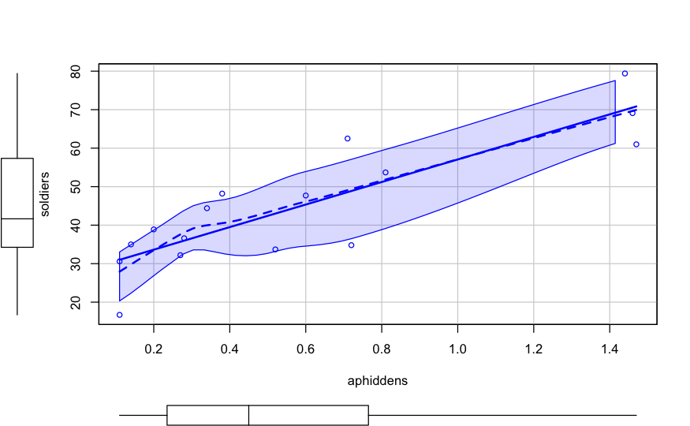

```r
scatterplot (soldiers~aphiddens, data=shibao)
```

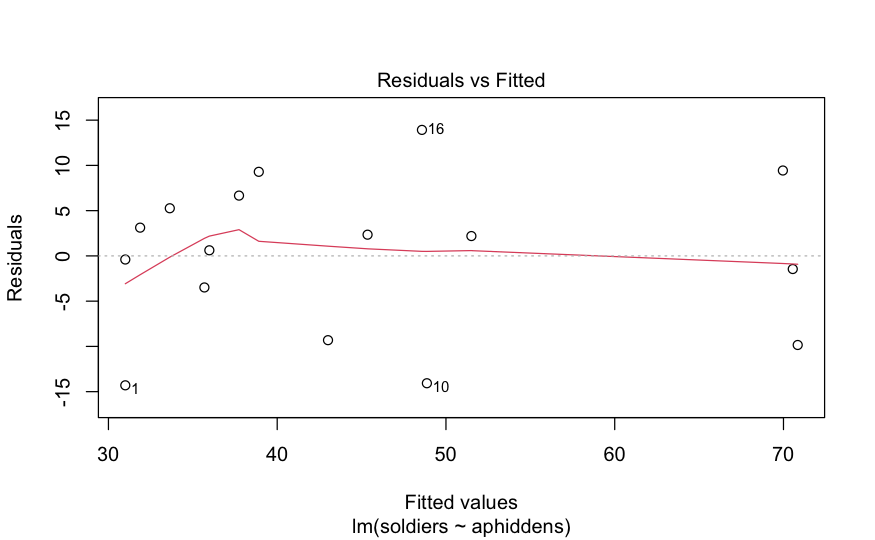

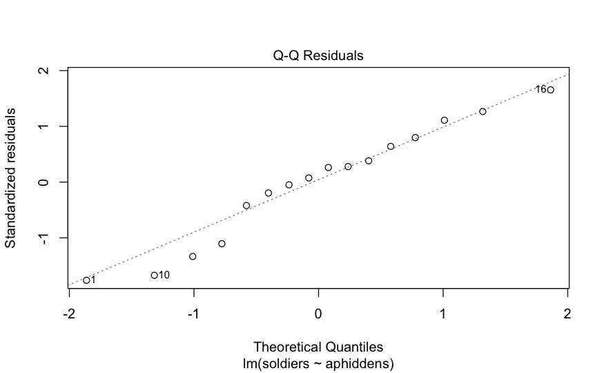

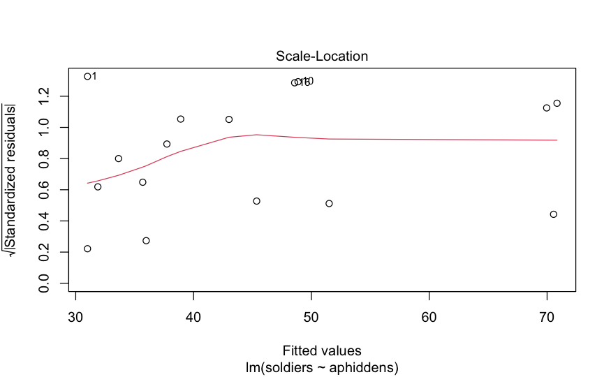

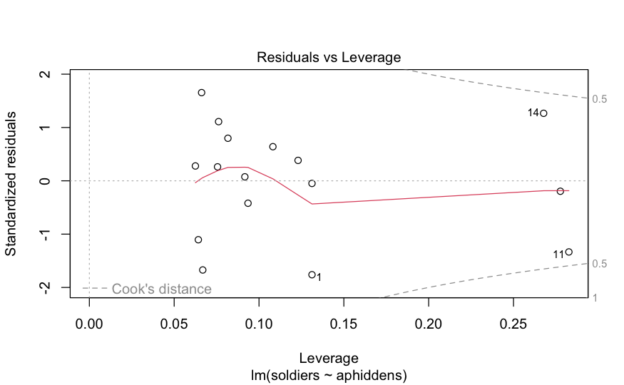

```r
shibao.lm <- lm(soldiers~aphiddens, data=shibao)
plot(shibao.lm)
```

```r
# influence.measures(shibao.lm)
augment(shibao.lm,data=shibao)
```

| holenum | colsize | soldiers | aphiddens | soldiers.1 | .fitted | .resid | .hat | .sigma | .cooksd | .std.resid |
| --- | --- | --- | --- | --- | --- | --- | --- | --- | --- | --- |
| 13 | 389 | 16.7 | 0.11 | 16.7 | 30.99892 | -14.2989210 | 0.13122452 | 7.975101 | 0.2342664506 | -1.76123106 |
| 46 | 1263 | 30.6 | 0.11 | 30.6 | 30.99892 | -0.3989210 | 0.13122452 | 9.038327 | 0.0001823381 | -0.04913602 |
| 49 | 2848 | 38.9 | 0.20 | 38.9 | 33.63566 | 5.2643413 | 0.10819164 | 8.905899 | 0.0248451937 | 0.63999284 |
| 36 | 3326 | 35.0 | 0.14 | 35.0 | 31.87783 | 3.1221664 | 0.12302637 | 8.991686 | 0.0102763988 | 0.38276272 |
| 60 | 7707 | 32.2 | 0.27 | 32.2 | 35.68645 | -3.4864546 | 0.09351595 | 8.981868 | 0.0091166877 | -0.42040781 |
| 42 | 2812 | 36.6 | 0.28 | 36.6 | 35.97943 | 0.6205745 | 0.09165076 | 9.037302 | 0.0002819174 | 0.07475399 |
| 34 | 5770 | 44.4 | 0.34 | 44.4 | 37.73725 | 6.6627494 | 0.08167419 | 8.831022 | 0.0283336080 | 0.79821876 |
| 43 | 7456 | 48.2 | 0.38 | 48.2 | 38.90913 | 9.2908660 | 0.07617984 | 8.632374 | 0.0507786636 | 1.10976066 |
| 73 | 15820 | 33.7 | 0.52 | 33.7 | 43.01073 | -9.3107259 | 0.06423686 | 8.635928 | 0.0419105391 | -1.10501309 |
| 35 | 14846 | 34.8 | 0.72 | 34.8 | 48.87014 | -14.0701429 | 0.06683945 | 8.086180 | 0.1001430552 | -1.67219596 |

[output cut: 6 more lines]

### Examine model output

We’re comfortable with the diagnostics, so we can now assess the parameters and their confidence intervals:

$$\operatorname{\widehat{soldiers}} = 27.78 +
29.3(\operatorname{aphiddens})$$

```r
tidy(shibao.lm, conf.int = TRUE)
```

| term | estimate | std.error | statistic | p.value | conf.low | conf.high |
| --- | --- | --- | --- | --- | --- | --- |
| (Intercept) | 27.77624 | 3.546041 | 7.833028 | 1.749056e-06 | 20.17074 | 35.38174 |
| aphiddens | 29.29709 | 4.683973 | 6.254751 | 2.109869e-05 | 19.25096 | 39.34321 |

```r
glance(shibao.lm)
```

| r.squared | adj.r.squared | sigma | statistic | p.value | df | logLik | AIC | BIC | deviance | df.residual | nobs |
| --- | --- | --- | --- | --- | --- | --- | --- | --- | --- | --- | --- |
| 0.7364553 | 0.7176306 | 8.710301 | 39.12191 | 2.109869e-05 | 1 | -56.26687 | 118.5337 | 120.8515 | 1062.171 | 14 | 16 |

```r
anova(shibao.lm)
```

```
Analysis of Variance Table

Response: soldiers
          Df Sum Sq Mean Sq F value   Pr(>F)
aphiddens  1 2968.2 2968.15  39.122 2.11e-05 ***
Residuals 14 1062.2   75.87
---
Signif. codes:  0 ‘***’ 0.001 ‘**’ 0.01 ‘*’ 0.05 ‘.’ 0.1 ‘ ’ 1
```

Get standardized coefficients

```r
lm.beta(shibao.lm)
```

```
Call:
lm(formula = soldiers ~ aphiddens, data = shibao)

Standardized Coefficients::
(Intercept)   aphiddens
         NA   0.8581697
```

## Bibliography

Shibao, Harunobu, Mayako Kutsukake, and Takema Fukatsu. 2004. “Density Triggers Soldier Production in a Social Aphid.” *Proceedings of the Royal Society of London. Series B: Biological Sciences* 271 (suppl_3). https://doi.org/fwhx8g.

Shibao, Harunobu, Mayako Kutsukake, Shigeru Matsuyama, Takema Fukatsu, and Masakazu Shimada. 2010. “Mechanisms Regulating Caste Differentiation in an Aphid Social System.” *Communicative & Integrative Biology* 3 (1): 1–5. https://doi.org/dnj3d4.